# ECON 339 - Tuesday/Thursday Week 8

Author

Matina Lampsas

Published

May 21, 2024

# Setup

```r
library(tidyverse)
library(readxl)
library(car)
options(scipen = 999)
```

# Tuesday Notes

## Read in the Data

```r
#read in the data for the wages
satisfaction_data <- read_xlsx(here::here("data",
                     "Data for Weeks 7-10.xlsx"),
                      sheet = "Satisfaction"
                     )
```

## Practice Problem:

### Estimate the true and used models:

```r
true_model <- lm(Satisfaction ~ Salary+Hours, data = satisfaction_data)
used_model <- lm(Satisfaction ~ Salary, data = satisfaction_data)

summary(true_model)
```

```
Call:
lm(formula = Satisfaction ~ Salary + Hours, data = satisfaction_data)

Residuals:
     Min       1Q   Median       3Q      Max
-25.7671  -8.4185  -0.8451   7.5820  26.2216

Coefficients:
            Estimate Std. Error t value            Pr(>|t|)
(Intercept) 58.27706    4.35380   13.38 <0.0000000000000002 ***
Salary       2.37473    0.07397   32.10 <0.0000000000000002 ***
Hours       -3.46954    0.11681  -29.70 <0.0000000000000002 ***
---
Signif. codes:  0 '***' 0.001 '**' 0.01 '*' 0.05 '.' 0.1 ' ' 1

Residual standard error: 11.46 on 197 degrees of freedom
Multiple R-squared:  0.8571,    Adjusted R-squared:  0.8556
F-statistic: 590.6 on 2 and 197 DF,  p-value: < 0.00000000000000022
```

```r
summary(used_model)
```

```
Call:
lm(formula = Satisfaction ~ Salary, data = satisfaction_data)

Residuals:
    Min      1Q  Median      3Q     Max
-54.936 -23.961   3.057  22.989  51.012

Coefficients:
            Estimate Std. Error t value         Pr(>|t|)
(Intercept)  -9.7376     8.6453  -1.126            0.261
Salary        0.9953     0.1344   7.405 0.00000000000369 ***
---
Signif. codes:  0 '***' 0.001 '**' 0.01 '*' 0.05 '.' 0.1 ' ' 1

Residual standard error: 26.75 on 198 degrees of freedom
Multiple R-squared:  0.2169,    Adjusted R-squared:  0.2129
F-statistic: 54.83 on 1 and 198 DF,  p-value: 0.000000000003687
```

Looking at the Summaries of the True and Used models we can better understand the bias and if Endogeneity is present in the model.

True Model: There is a positive correlation between salary and satisfaction, but there is a negative correlation between hours and satisfaction. This shows a negative bias

## Practice Problem - Heteroskedasticity

Consider a simple regression model that relates monthly sales (Sales in $1,000s) from a chain of convenience stores with the square footage (Sqft) of the store. (Data: Stores) • You would expect sales to vary more as square footage increases. For instance, a small convenience store is likely to include only bare essentials for which there is a fairly stable demand. A larger store, on the other hand, may include specialty items, resulting in more fluctuation in sales

```r
#read in the data for the wages
stores_data <- read_xlsx(here::here("data",
                     "Data for Weeks 7-10.xlsx"),
                      sheet = "Stores"
                     )
```

### Make a residuals vs fitted plot:

In order to better understand if we have heteroskedasticity present, lets make a residuals vs fitted plot:

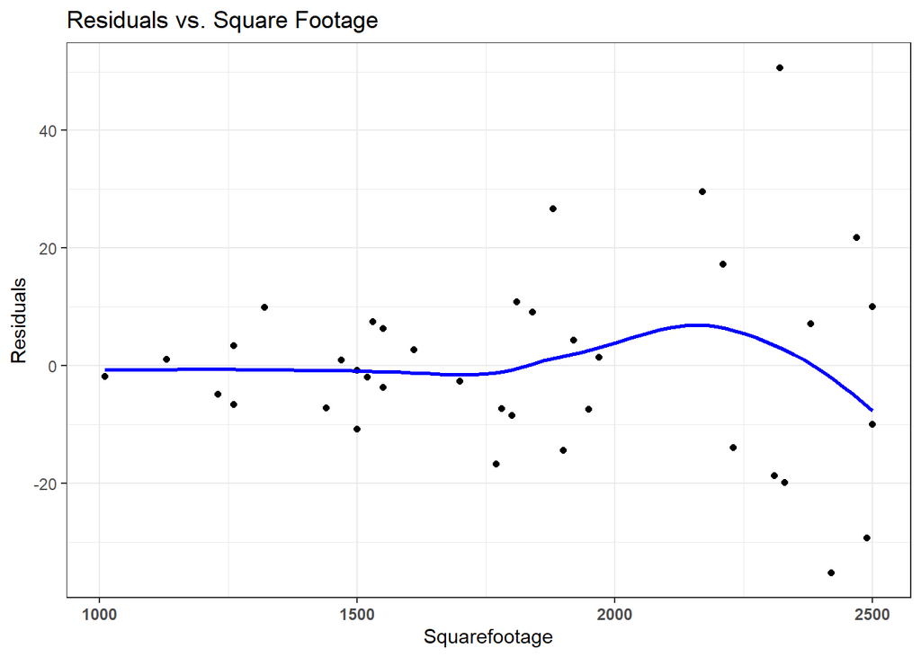

```r
stores_lm <- lm(Sales ~ Sqft, data = stores_data)

# Add residuals and the square root of the predictor variable to the data frame
stores_data <- stores_data %>%
  mutate(residuals = resid(stores_lm))

stores_data %>%
  ggplot(aes(x = Sqft, y = residuals)) +
  geom_point() +
  geom_smooth(method = "loess", se = FALSE, color = "blue") +  # Optional: add a smooth line
  labs(title = "Residuals vs. Square Footage",
       x = "Squarefootage",
       y = "Residuals") +
  theme_bw()+
  theme(axis.text.x = element_text(face = "bold"))
```

```r
# load in the libraries:
library(lmtest)
library(sandwich)
```

### To calculate robust standard error:

```r
coeftest(stores_lm, vcov. = vcovHC(stores_lm, type = "HC1"))
```

```
t test of coefficients:

              Estimate Std. Error t value        Pr(>|t|)
(Intercept) 22.0795111  9.5630163  2.3088         0.02649 *
Sqft         0.0591479  0.0064415  9.1823 0.0000000000346 ***
---
Signif. codes:  0 '***' 0.001 '**' 0.01 '*' 0.05 '.' 0.1 ' ' 1
```

## Practice Problem 3:

```r
# load in the data
#read in the data for the college
college_data <- read_xlsx(here::here("data",
                     "Data for Weeks 2-7.xlsx"),
                      sheet = "College",
                     range = "A1:G117",
                      n_max = 118
                      )
```

### Make your linear regression model:

```r
college_lm <- lm(Earnings ~ Cost + Grad + Debt + City, data = college_data)
summary(college_lm)
```

```
Call:
lm(formula = Earnings ~ Cost + Grad + Debt + City, data = college_data)

Residuals:
     Min       1Q   Median       3Q      Max
-12375.3  -3065.2   -589.9   2946.5  20189.0

Coefficients:
              Estimate Std. Error t value Pr(>|t|)
(Intercept) 10004.9665  7634.3338   1.311 0.192724
Cost            0.4349     0.1110   3.917 0.000155 ***
Grad          178.0989    69.1940   2.574 0.011373 *
Debt          141.4783   117.2120   1.207 0.229987
City         2526.7888  1103.4026   2.290 0.023912 *
---
Signif. codes:  0 '***' 0.001 '**' 0.01 '*' 0.05 '.' 0.1 ' ' 1

Residual standard error: 5646 on 111 degrees of freedom
Multiple R-squared:  0.4292,    Adjusted R-squared:  0.4087
F-statistic: 20.87 on 4 and 111 DF,  p-value: 0.0000000000007564
```

### Make your graphs:

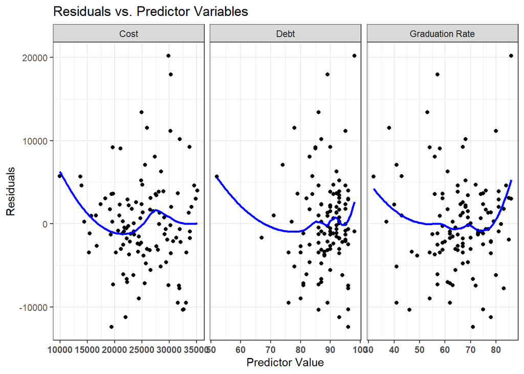

```r
# Add residuals to the data frame
college_data <- college_data %>%
  mutate(residuals = resid(college_lm))

# Reshape the data for ggplot
long_data <- college_data %>%
  pivot_longer(cols = c(Cost, Grad, Debt), names_to = "variable", values_to = "value")

# Create the ggplot
long_data %>%
  ggplot(aes(x = value, y = residuals)) +
  geom_point() +
  geom_smooth(method = "loess", se = FALSE, color = "blue") +  # Optional: add a smooth line
  labs(
    title = "Residuals vs. Predictor Variables",
    x = "Predictor Value",
    y = "Residuals"
  ) +
  theme_bw() +
  facet_grid(~ variable, scales = "free_x", labeller = labeller(variable = c(Cost = "Cost", Grad = "Graduation Rate", Debt = "Debt"))) +  # Proper labels for each panel
  theme(axis.text.x = element_text(face = "bold"))
```

```r
###### ALTERNATIVE WAY TO GRAPH THE RESIDUALS PLOT:
# Residuals <- resid(college_lm)
# yHat <- predict(college_lm)
# plot(college_data$Cost, Residuals, xlab="Cost", ylab="e")
# plot(college_data$Grad, Residuals, xlab="Grad", ylab="e")
# plot(college_data$Debt, Residuals, xlab="Debt", ylab="e")
# plot(yHat, Residuals, xlab="y-hat", ylab="e")
# abline(h=0, col = "red")
```

# Thursday Notes:

## Linear Probability Model (LPM):

- What it is: regression model applied to binary dependent variables
- Why is it called linear probability model?
  - y is a discrete value. The possible values are either 0 or 1, its conditional expected value cal be computed as E(y) = 0 x P(y=0) + 1 x P(y=1) = P(y=1)
  - Predictions with this model are made by phat = yhat = x’b where b is a vector of the estimated coefficients

### Example - copy and pasted from slides:

Consider the relationship between exposure to bad air in a polluted city and the likelihood of developing respiratory illnesses . Data include the daily average number of minutes spent outdoors without a mask (Minutes) and whether the individual has been diagnosed with a respiratory illness (Illness). Here ‘Illness’ is the response variable and ‘Minutes’ the predictor variable. Estimate and interpret the LPM to predict the respiratory illness probability for an individual who spends an average of eight hours outdoors without a mask. (Data: **Pollution**)

- The estimated LPM model is –> Illness = −0.1291 + 0.0011Minutes.
- For eight hours (or 480 minutes) the predicted probability of illness equals −0.1291 + 0.0011 × 480 = 0.3838, or 38.38%.

  ```r
  # Practice Problem (Hetero)
  #read in the data
  polut_data <- read_xlsx(here::here("data",
                       "Data for Weeks 7-10.xlsx"),
                        sheet = "Pollution"
                       )
  ## professors code --- note: it is in base r
  Linear_Model <- lm(Illness~Minutes, data = polut_data)
  summary(Linear_Model)
  ```

  ```
  Call:
  lm(formula = Illness ~ Minutes, data = polut_data)

  Residuals:
       Min       1Q   Median       3Q      Max
  -0.85182 -0.29566 -0.03655  0.31807  0.95704

  Coefficients:
                Estimate Std. Error t value            Pr(>|t|)
  (Intercept) -0.1290692  0.0632695  -2.040              0.0426 *
  Minutes      0.0010685  0.0001126   9.487 <0.0000000000000002 ***
  ---
  Signif. codes:  0 '***' 0.001 '**' 0.01 '*' 0.05 '.' 0.1 ' ' 1

  Residual standard error: 0.4155 on 218 degrees of freedom
  Multiple R-squared:  0.2922,    Adjusted R-squared:  0.2889
  F-statistic: 89.99 on 1 and 218 DF,  p-value: < 0.00000000000000022
  ```

  ```r
  predict(Linear_Model, data.frame(Minutes=480)) # 8 hrs
  ```

  ```
          1
  0.3838158
  ```

  ```r
  predict(Linear_Model, data.frame(Minutes=1200))# 20 hrs
  ```

  ```
         1
  1.153143
  ```

  ```r
  predict(Linear_Model, data.frame(Minutes=60)) # 1 hr
  ```

  ```
            1
  -0.06495859
  ```

#### Limitations of LPM:

1. LPM doesn’t constrain the predicted probabilities between 0 and 1
2. The linearity of the relationship may also be questionable. LPM assumes that an extra hour (60 min) outdoors without a mask increases the illness probability by 0.066, regardless of whether the increase is from 1 to 2 hours or from 20 to 21 hours.

### Practice Problem:

Consider a binary response variable, y, along with four explanatory variables: x<sub>2</sub> ,x<sub>3</sub> ,x<sub>4</sub> and x<sub>5</sub> . Use the entire data for the analysis (Data = **Practice**)

#### 1. Estimate a Linear Probability Model (LPM) with x<sub>2</sub> ,x<sub>3</sub> ,x<sub>4</sub> and x<sub>5</sub> as the explanatory variables.

```r
#read in the data
practice_data <- read_xlsx(here::here("data",
                     "Data for Weeks 7-10.xlsx"),
                      sheet = "Practice"
                     )
prac_lpm <- lm(y~x2+x3+x4+x5,data=practice_data)
summary(prac_lpm)
```

```
Call:
lm(formula = y ~ x2 + x3 + x4 + x5, data = practice_data)

Residuals:
     Min       1Q   Median       3Q      Max
-0.92185 -0.02619  0.04446  0.10700  0.27362

Coefficients:
               Estimate  Std. Error t value             Pr(>|t|)
(Intercept)  1.20718760  0.06696208  18.028 < 0.0000000000000002 ***
x2           0.00554422  0.00104977   5.281 0.000000180055935866 ***
x3          -0.00518449  0.00062710  -8.267 0.000000000000000896 ***
x4           0.00005562  0.00155967   0.036               0.9716
x5          -0.00169358  0.00077580  -2.183               0.0294 *
---
Signif. codes:  0 '***' 0.001 '**' 0.01 '*' 0.05 '.' 0.1 ' ' 1

Residual standard error: 0.2172 on 595 degrees of freedom
Multiple R-squared:  0.1486,    Adjusted R-squared:  0.1429
F-statistic: 25.96 on 4 and 595 DF,  p-value: < 0.00000000000000022
```

#### 2. For interpretation, simulate the predicted probabilities w.r.t reasonable values of x<sub>2</sub> (say between 10 and 40). Use average values for x<sub>3</sub> ,x<sub>4</sub> and x<sub>5</sub> .

```r
# copied from professor code --BASE R :(
sx2 <- 11:40
mx3 <- mean(practice_data$x3)
mx4 <- mean(practice_data$x4)
mx5 <- mean(practice_data$x5)

mx3; mx4; mx5
```

```
[1] 64.66428
```

```
[1] 19.87772
```

```
[1] 40.73387
```

#### 3. Make a plot with the simulated values in part 2

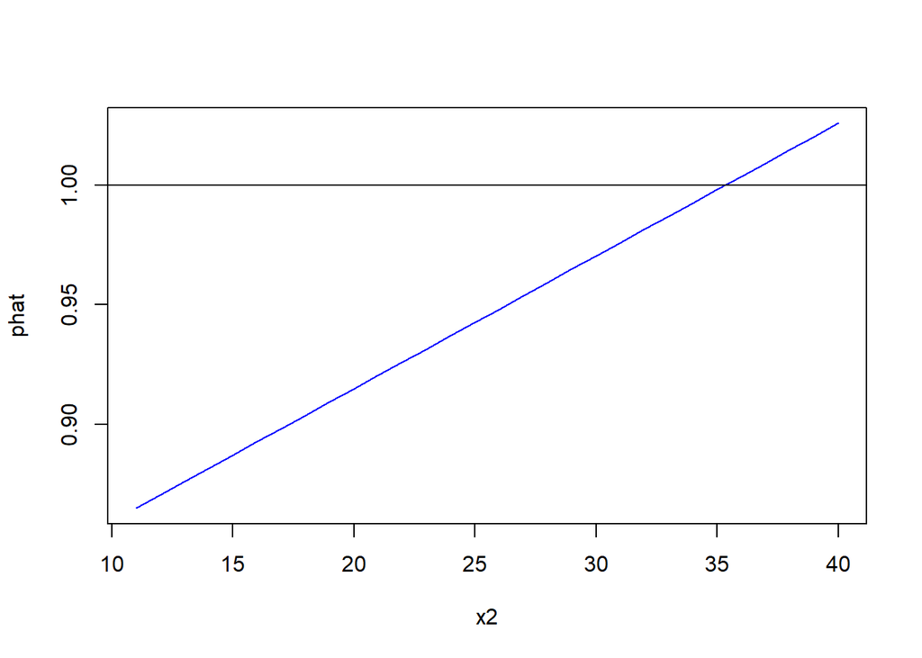

```r
yhat <- predict(prac_lpm, data.frame(x2=sx2, x3=mx3, x4=mx4, x5=mx5))
plot(sx2,yhat,type="l",lwd=1, col="blue", xlab="x2", ylab="phat")
abline(h=1)
```

#### 4. At what approximate value of x<sub>2</sub> does the predicted probability exceed 1.0?

```r
cbind(sx2,yhat)
```

```
   sx2      yhat
1   11 0.8650420
2   12 0.8705862
3   13 0.8761305
4   14 0.8816747
5   15 0.8872189
6   16 0.8927631
7   17 0.8983073
8   18 0.9038516
9   19 0.9093958
10  20 0.9149400
11  21 0.9204842
12  22 0.9260285
13  23 0.9315727
14  24 0.9371169
```

[output cut: 16 more lines]

## Logistic Regression Model:

- With linear specification phat=x’b, we cannot avoid probabilities going outside [0,1]
- we need an “S-shaped” specification that constrains the probability between [0,1]
- In order to transform a model to account for limitations found in LPM model, we make a sigmoid specification that way the probability is only between 0 and 1.
  - no need to create a plot for LPM because OLS coefficients are easy to interpret

[figure not shown]

The logistic specification is given by $\hat{p} = \frac{\exp(x'b)}{1 + \exp(x'b)} = \frac{1}{1 + \exp(-x'b)}$

- constrains the probability between 0 and 1
- accommodates a non-linear relationship
- uses MLE

### Practice Problem:

Peter Derby works as a cybersecurity analyst at a private equity firm. His colleagues at the firm have been inundated with a large number of spam emails. Peter has been asked to implement a spam detection system on the company’s email server. He analyzes a sample of 500 spam and legitimate emails with the following relevant variables: spam (1 if spam, 0 otherwise), the number of recipients, the number of hyperlinks, and the number of characters in the message.(Data = **Spam**)

#### 1. Estimate the linear probability model and the logistic regression model for spam detection.

```r
#read in the data
spam_data <- read_xlsx(here::here("data",
                     "Data for Weeks 7-10.xlsx"),
                      sheet = "Spam"
                     )

spam_lm <- lm(Spam ~ Recipients + Hyperlinks + Characters, data = spam_data)
summary(spam_lm)
```

```
Call:
lm(formula = Spam ~ Recipients + Hyperlinks + Characters, data = spam_data)

Residuals:
     Min       1Q   Median       3Q      Max
-0.89234 -0.31244  0.02357  0.23996  1.01710

Coefficients:
              Estimate Std. Error t value             Pr(>|t|)
(Intercept) -0.1408028  0.0837919  -1.680             0.093512 .
Recipients   0.0157683  0.0041537   3.796             0.000165 ***
Hyperlinks   0.0879229  0.0050071  17.560 < 0.0000000000000002 ***
Characters  -0.0020144  0.0007255  -2.776             0.005705 **
---
Signif. codes:  0 '***' 0.001 '**' 0.01 '*' 0.05 '.' 0.1 ' ' 1

Residual standard error: 0.3901 on 496 degrees of freedom
Multiple R-squared:  0.3955,    Adjusted R-squared:  0.3918
F-statistic: 108.2 on 3 and 496 DF,  p-value: < 0.00000000000000022
```

```r
spam_logit <- glm(Spam ~ Recipients + Hyperlinks + Characters, family = binomial, data = spam_data)
summary(spam_logit)
```

```
Call:
glm(formula = Spam ~ Recipients + Hyperlinks + Characters, family = binomial,
    data = spam_data)

Coefficients:
             Estimate Std. Error z value             Pr(>|z|)
(Intercept) -3.824254   0.635519  -6.018        0.00000000177 ***
Recipients   0.107522   0.032179   3.341             0.000834 ***
Hyperlinks   0.513269   0.044508  11.532 < 0.0000000000000002 ***
Characters  -0.014112   0.004923  -2.866             0.004153 **
---
Signif. codes:  0 '***' 0.001 '**' 0.01 '*' 0.05 '.' 0.1 ' ' 1

(Dispersion parameter for binomial family taken to be 1)

    Null deviance: 692.64  on 499  degrees of freedom
Residual deviance: 456.94  on 496  degrees of freedom
AIC: 464.94

Number of Fisher Scoring iterations: 5
```

#### 2. Use simulations to highlight the partial effect of Recipients on the predicted spam probability, while holding Hyperlinks and Characters fixed at their sample means

```r
predict(spam_lm, data.frame(Recipients=15, Hyperlinks=5, Characters=100))
```

```
        1
0.3338975
```

```r
predict(spam_logit, data.frame(Recipients=15, Hyperlinks=5, Characters=100), type = "response")
```

```
        1
0.2580198
```

```r
mRec <- seq(0,50,by = 1) #same as 0:50
```

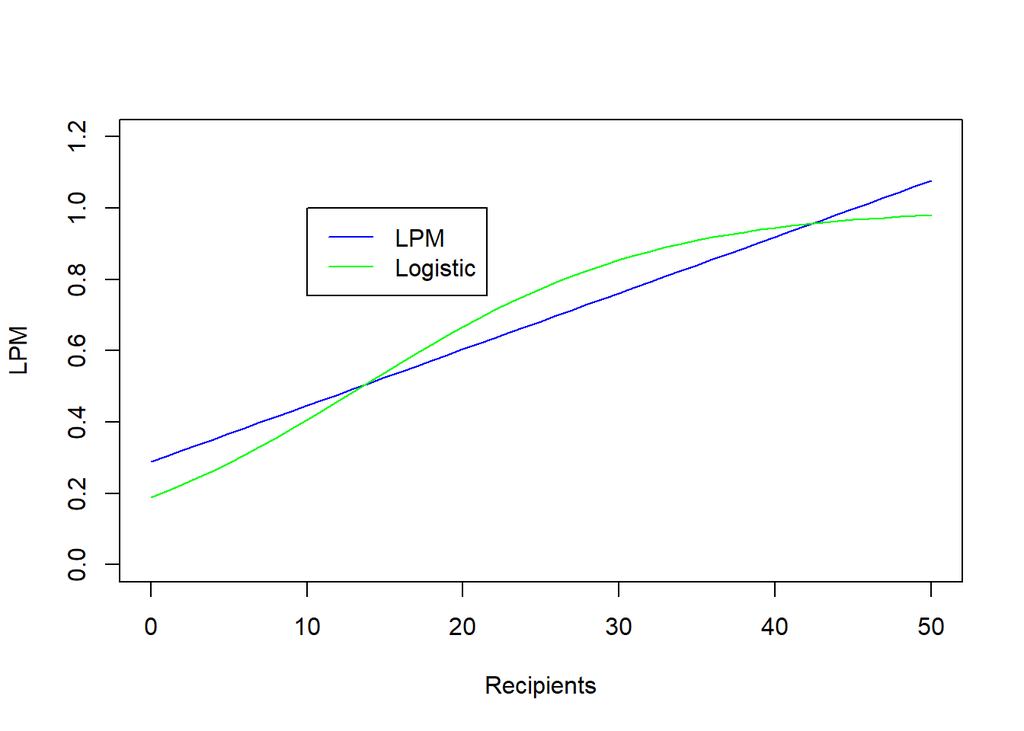

```r
mHyp <- mean(spam_data$Hyperlinks)
mCha <- mean(spam_data$Characters)
pLin <- predict(spam_lm, data.frame(Recipients=mRec, Hyperlinks=mHyp, Characters=mCha))
pLog <- predict(spam_logit, data.frame(Recipients=mRec, Hyperlinks=mHyp, Characters=mCha), type = "response")
plot(mRec,pLin,type="l",lwd=1, ylim=c(0,1.2), col="blue", xlab="Recipients", ylab="LPM")
lines(mRec,pLog,type="l",lwd=1, col="green")
legend(10,1.0,c("LPM","Logistic"), lwd=c(1,1), col=c("blue","green"))
```